# DATA Assessment 2023-24

## Department of Computer Science, University of York

### DATA: Introduction to Data Science

## Task 1: Domain Analysis (5 marks)

Given the business domain and the data overview presented (in the assessment paper), provide a brief description of

- the business problem and its significance to the relevant sector;
- the link between the business problem and the field of data science;
- the main areas of investigation; and
- potential ideas and solutions.

**Word Limit:** 300 words

**Write your answer here (text cell(s) to be used, as appropriate)**

```python
'''
Business Problem and its Significance:

    The primary business problem revolves around efficiently managing and utilizing extensive financial data to enhance banking services and operations.
    This task is crucial in the banking sector as it directly influences customer satisfaction, risk management, and overall financial stability. Effective
    handling of data can lead to improved decision-making processes, personalized banking services, better risk assessment, fraud detection, and more
    efficient operational strategies.

Link to Data Science:

    Data science plays a pivotal role in solving this business problem by providing tools and methodologies for analyzing large datasets, extracting meaningful
    patterns, and generating insights. Through techniques like data mining, statistical analysis, and predictive modeling, data science can transform raw
    data into actionable knowledge. This is particularly relevant in banking, where data-driven insights can optimize financial products, personalize
    customer experiences, and enhance security measures.

Main Areas of Investigation:

    1. Customer Behavior Analysis: Understanding how clients interact with banking services, such as types of transactions, loan uptake, and credit card usage.
    2. Risk Assessment and Management: Identifying patterns that signal potential risks, like loan defaults or fraudulent activities.
    3. Operational Efficiency: Analyzing transaction data to streamline banking operations and improve service delivery.
    4. Personalization of Services: Tailoring banking products based on customer profiles and transaction histories.
    5. Market Trends and Forecasting: Using demographic and financial data to anticipate market shifts and develop proactive strategies.

Potential Ideas and Solutions:

    1. Predictive Analytics for Risk Management: Implementing machine learning models to predict loan defaults or detect unusual transaction patterns indicating fraud.
    2. Customer Segmentation: Utilizing clustering techniques to segment customers based on transaction behaviors, enabling personalized marketing and service offerings.
    3. Operational Analytics: Analyzing transaction data to identify bottlenecks and optimize processes for faster service delivery.
    4. Data Visualization Tools: Developing dashboards for real-time monitoring of financial activities and customer interactions.
    5. Trend Analysis for Strategic Planning: Employing time-series analysis to understand market dynamics and assist in strategic decision-making.

    In summary, the application of data science in this scenario can significantly enhance the efficiency and effectiveness of banking operations, leading to improved customer
    experiences, risk management, and overall financial performance.
'''
```

## Task 2: Database Design (25 marks)

Having understood the business domain, present a conceptual design in the form of an entity-relationship (ER) model that would be helpful in creating a database for the bank.

The bank data currently exists in the form of a csv file called *BankRecords.csv*, provided on VLE (path given in page 5, assessment paper). This file has all the existing records. The table available in the csv file is unnormalised. The information about its different columns is given in Tables 1 and 2 (in the assessment paper).

Following the standard principles of database normalisation, normalise the given table (*BankRecords.csv*) to a database schema that has minimum redundancies. Then, using the designed schema, create an SQLite database.

Your answer should include the SQL statements needed to accomplish this step. Your submission should also include the created SQLite database file.

Your answer should clearly cover the following:

- Any assumptions you are making about the given scenario;
- The designated keys, existing relationships, and identified functional dependencies;
- The steps followed and justifications for the decisions made.

**World Limit**: 500 words. This limit applies only to the explanations. There is no limit on any associated code/SQL statements or figures.

**Write your answer here (text cell(s) to be used, as appropriate)**

```python
'''
1. Assumptions:

    * Each attribute in the given dataset is correctly filled with no missing values unless specified as optional.
    * The account identifiers and client identifiers uniquely identify accounts and clients, respectively.
    * The CSV data will be imported into the database without any preprocessing unless specified.

2. Designated Keys, Relationships, and Functional Dependencies:

    A. Designated Keys: account_id, loan_id, order_id, trans_id, disp_id, client_id, and card_id will act as primary keys for their respective entities.

    B. Existing Relationships:
        * An account can have multiple transactions, loans, and orders but is managed by a single client (owner or disponent).
        * A client can have multiple dispositions, accounts, and credit cards.

    C. Identified Functional Dependencies:
        * account_id → frequency, creation_date
        * loan_id → loan_date, loan_amount, loan_duration, loan_payments, loan_status
        * order_id → bank_to, account_to, order_amount, payment_type
        * trans_id → trans_date, trans_type, operation, trans_amount, balance, trans_detail, partner_bank, partner_account
        * disp_id → client_id, account_id, disp_type
        * card_id → disp_id, card_type, card_issued
        * client_id → birth_number

3. Normalization Process:

    Step 1: Identify entities and relationships. Create a separate table for each entity and define relationships between them.
    Step 2: Apply the first normal form (1NF) by eliminating repeating groups and ensuring atomicity.
    Step 3: Apply the second normal form (2NF) by removing partial dependencies of non-key attributes on any candidate key.
    Step 4: Apply the third normal form (3NF) by removing transitive dependencies of non-key attributes on any candidate key.

4. SQL Statements and Justifications:

    The SQL statements will create tables based on the normalized schema.
    Tables will be created for clients, accounts, dispositions, transactions, orders, loans, and credit cards, each with appropriate foreign keys to enforce relationships.
    The following is a high-level SQL schema definition based on the given attributes and assumptions:

    -- Clients Table
    CREATE TABLE Clients (
        client_id INTEGER PRIMARY KEY,
        birth_number VARCHAR(10) NOT NULL
    );

    -- Accounts Table
    CREATE TABLE Accounts (
        account_id INTEGER PRIMARY KEY,
        frequency VARCHAR(20),
        creation_date DATE NOT NULL
    );

    -- Dispositions Table
    CREATE TABLE Dispositions (
        disp_id INTEGER PRIMARY KEY,
        client_id INTEGER NOT NULL,
        account_id INTEGER NOT NULL,
        disp_type VARCHAR(7),
        FOREIGN KEY (client_id) REFERENCES Clients(client_id),
        FOREIGN KEY (account_id) REFERENCES Accounts(account_id)
    );

    -- Transactions Table
    CREATE TABLE Transactions (
        trans_id INTEGER PRIMARY KEY,
        account_id INTEGER NOT NULL,
        trans_date DATE,
        trans_type VARCHAR(20),
        operation VARCHAR(30),
        trans_amount DECIMAL(10,2),
        balance DECIMAL(10,2),
        trans_detail VARCHAR(50),
        partner_bank VARCHAR(2),
        partner_account VARCHAR(16),
        FOREIGN KEY (account_id) REFERENCES Accounts(account_id)
    );

    -- Orders Table
    CREATE TABLE Orders (
        order_id INTEGER PRIMARY KEY,
        account_id INTEGER NOT NULL,
        bank_to VARCHAR(2),
        account_to VARCHAR(16),
        order_amount DECIMAL(10,2),
        payment_type VARCHAR(30),
        FOREIGN KEY (account_id) REFERENCES Accounts(account_id)
    );

    -- Loans Table
    CREATE TABLE Loans (
        loan_id INTEGER PRIMARY KEY,
        account_id INTEGER NOT NULL,
        loan_date DATE,
        loan_amount DECIMAL(10,2),
        loan_duration INTEGER,
        loan_payments DECIMAL(10,2),
        loan_status CHAR(1),
        FOREIGN KEY (account_id) REFERENCES Accounts(account_id)
    );

    -- Credit Cards Table
    CREATE TABLE CreditCards (
        card_id INTEGER PRIMARY KEY,
        disp_id INTEGER NOT NULL,
        card_type VARCHAR(10),
        card_issued DATE,
        FOREIGN KEY (disp_id) REFERENCES Dispositions(disp_id)
    );

    This schema assumes that:

    * The birth_number can be used to uniquely identify clients along with client_id.
    * The disp_type indicates whether the disposition is an owner or a user.
    * Each loan_id, order_id, trans_id, and card_id is unique and independent of other identifiers.

Justifications for decisions made:

    * The database is normalized to 3NF to minimize redundancy and ensure data integrity.
    * client_id is a foreign key in Dispositions to link clients to their account dispositions.
    * account_id is a foreign key in Dispositions, Transactions, Orders, and Loans tables to associate these entities with a specific account.
    * Each entity table such as Loans, Orders, Transactions, and CreditCards has a foreign key to the Accounts or Dispositions table, establishing a one-to-many relationship (one account or disposition can be associated with multiple loans, orders, transactions, or credit cards, respectively).
    * Dates are assumed to be in the format YYYY-MM-DD for database compatibility.
    * The balance and trans_amount fields are of type DECIMAL to accurately represent monetary values, with a precision that covers typical transaction sizes.
'''
```

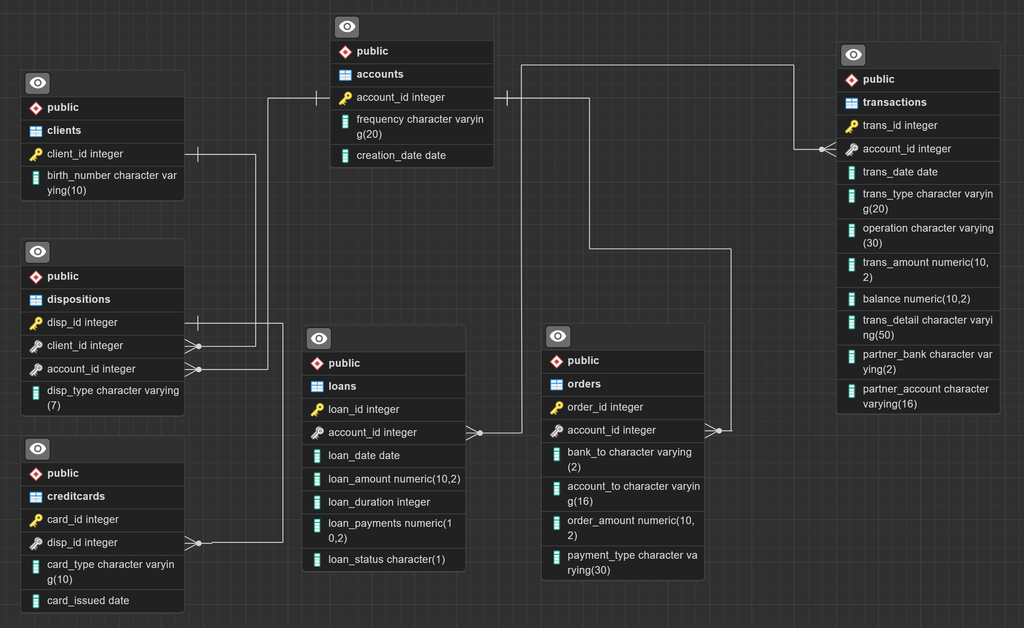

```python
from PIL import Image
from IPython.display import display
img = Image.open('ER.png')
display(img)
```

```python
# Database File Creation

import pandas as pd
import sqlite3
```

```python
# Load the CSV file into a pandas DataFrame
csv_file_path = 'BankRecords.csv'  # Replace with your CSV file path
bank_records_df = pd.read_csv(csv_file_path)

# Connect to the SQLite database (or create it if it doesn't exist)
database_path = 'BankRecords.db'
conn = sqlite3.connect(database_path)
```

```python
# Create 'Clients' Table
bank_records_df[['client_id', 'birth_number']].drop_duplicates().to_sql('Clients', conn, if_exists='replace', index=False)

# Create 'Accounts' Table
bank_records_df[['account_id', 'frequency', 'creation_date']].drop_duplicates().to_sql('Accounts', conn, if_exists='replace', index=False)

# Create 'Dispositions' Table
bank_records_df[['disp_id', 'client_id', 'account_id', 'disp_type']].drop_duplicates().to_sql('Dispositions', conn, if_exists='replace', index=False)

# Create 'Transactions' Table
transactions_columns = [
    'trans_id', 'account_id', 'trans_date', 'trans_type', 'operation',
    'trans_amount', 'balance', 'trans_detail', 'partner_bank', 'partner_account'
]
bank_records_df[transactions_columns].drop_duplicates().to_sql('Transactions', conn, if_exists='replace', index=False)

# Create 'Orders' Table
orders_columns = ['order_id', 'account_id', 'bank_to', 'account_to', 'order_amount', 'payment_type']
bank_records_df[orders_columns].drop_duplicates().to_sql('Orders', conn, if_exists='replace', index=False)

# Create 'Loans' Table
loans_columns = [
    'loan_id', 'account_id', 'loan_date', 'loan_amount', 'loan_duration',
    'loan_payments', 'loan_status'
]
bank_records_df[loans_columns].drop_duplicates().to_sql('Loans', conn, if_exists='replace', index=False)

# Create 'CreditCards' Table
credit_cards_columns = ['card_id', 'disp_id', 'card_type', 'card_issued']
bank_records_df[credit_cards_columns].drop_duplicates().to_sql('CreditCards', conn, if_exists='replace', index=False)
```

```
5369
```

```python
# close the database connection
conn.commit()
conn.close()

# After running this script, the SQLite database file 'BankRecords.db' will contain all the tables with the data imported from the CSV file.
```